# Formation FunQuant part 2

## Packages

```r
library(devtools)
install_github("tranvivielodie/GpOutput2D/GpOutput2D")
install.packages("rlibkriging")
install_github("CharlieSire/FunQuant", upgrade="never")
```

```r
library(FunQuant)
library(ggplot2)
library(randtoolbox)
library(evd)
```

## Variables

We consider $X = (X_{1},X_{2}) \in \mathbb{R}^2$ a random input of a computer code $H$, with
$$\left\{
\begin{array}{ll}
X_{1} \sim \mathcal{U}(-1,1)\\
X_{2} \sim tGEV(-0.4,0.1,0, -1, 1) \\
X_{1} \text{ and }X_{2}\text{ independent}
\end{array}
\right.$$

Where $tGEV(\mu,\sigma,\xi,a,b)$ is the generalized extreme value distribution of location $\mu$, scale $\sigma$ and shape $\xi$, truncated between $a$ and $b$.

```r
f2 = function(x){
  res = 0
  ptrunc = pgev(-1, loc=-0.4,scale=0.1) + 1 - pgev(1, loc=-0.4,scale=0.1)
  if(x>=-1 & x < 1){res = dgev(x, loc=-0.4,scale=0.1)/(1-ptrunc)}
  return(res)
}
f1 = function(x){
  if(x > -1 & x < 1){return(1/2)}
  else{return(0)}
}
fX = function(x){f1(x[1])*f2(x[2])}
```

The density of $X_{2}$ is represented in the next plot

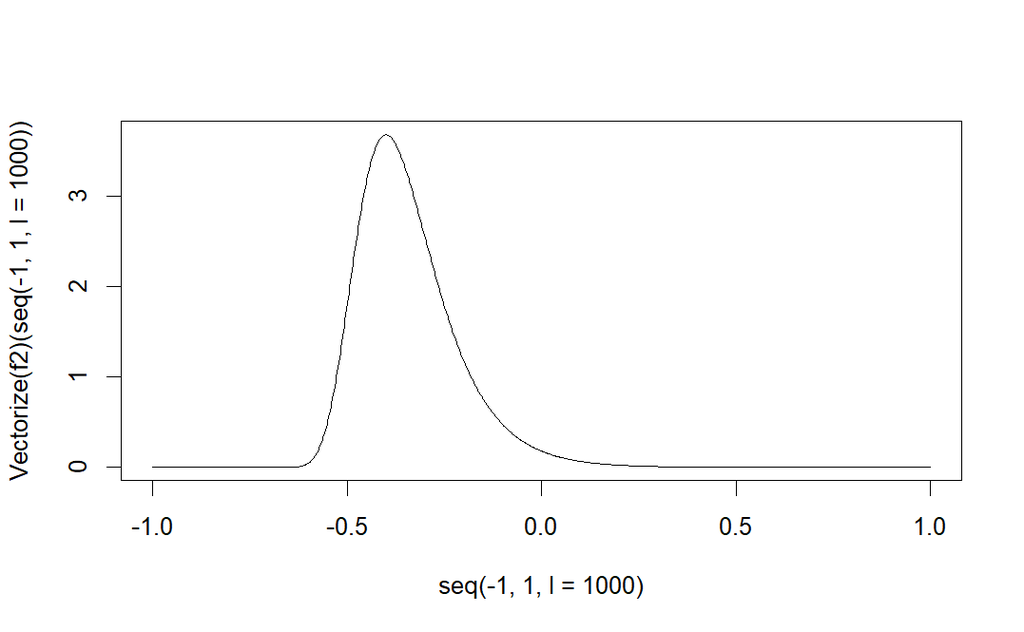

```r
plot(seq(-1,1,l=1000), Vectorize(f2)(seq(-1,1,l=1000)), type = "l")
```

The computer code $H$ return, for a given input $x \in \mathbb{R}^{2}$, a $20\times 20$ map.

We have $H(x) \approx 0$ if $x_{2} < -0.1.$

```r
step_conti = function(x){1/2*(1+2/pi*atan((x+0.1)*10^5))}

H <- function(X){
  Zgrid <- expand.grid(z1 = seq(-5,5,l=20),z2 = seq(-5,5,l=20))
  n<-nrow(X)
  Y <- lapply(1:n, function(i){step_conti(X[i,2])*(X[i,2]*X[i,1]*exp(-((0.8*Zgrid$z1+0.2*Zgrid$z2-10*X[i,1])**2)/(60*X[i,1]**2))*(Zgrid$z1-Zgrid$z2)*cos(X[i,1]*4)^2/log(7+Zgrid$z2+2.01+X[i,1]+X[i,2]) - Zgrid$z1/40*dnorm(cos(X[i,1])) + abs(Zgrid$z2)/30*dnorm(X[i,2]) + X[i,1] * sin(18.0 * X[i,1])/50)})
  Ymaps<- array(unlist(Y),dim=c(20,20,n))
  return(abs(Ymaps))
}
```

```r
plot_map = function(map, max = NULL, min = NULL){
  prototypes_toplot = expand.grid(seq(-5,5,l=20),seq(-5,5,l=20))
  prototypes_toplot$f = as.numeric(map)
  if(is.null(max))
  {p = ggplot(prototypes_toplot) + geom_raster(aes(x = Var1, y = Var2, fill = f)) + scale_fill_continuous(type = "viridis",direction = -1, name = "h") + theme_bw()}
  else{p = ggplot(prototypes_toplot) + geom_raster(aes(x = Var1, y = Var2, fill = f)) + scale_fill_continuous(type = "viridis", direction = -1, limits = c(min, max), name = "h") + theme_bw()  + theme(legend.text = element_text(size=13),legend.title = element_text(size=13))}
  return(p)
}
```

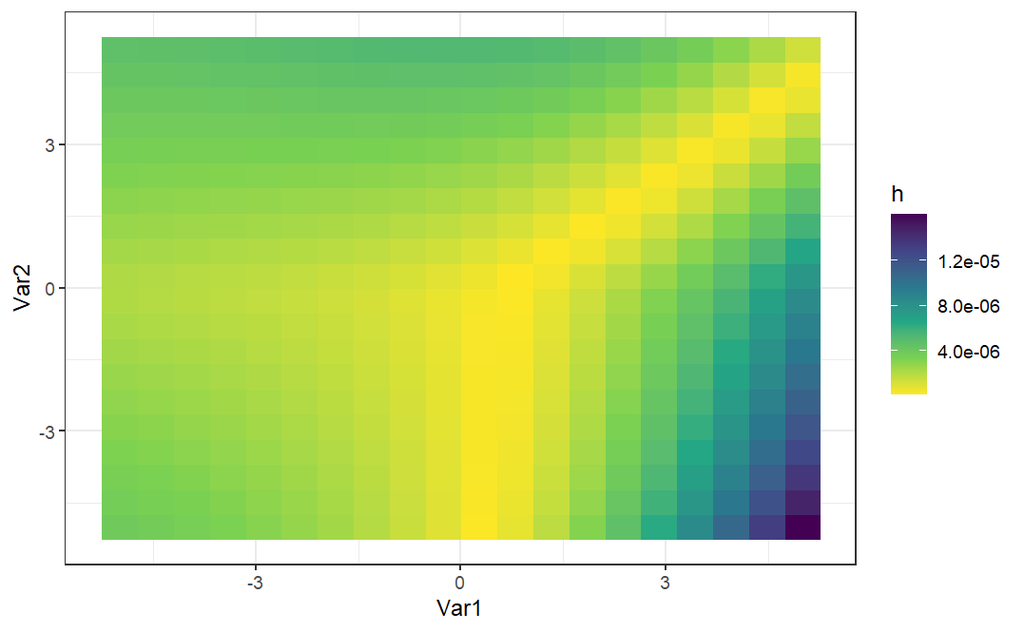

```r
plot_map(H(matrix(c(0.8,-0.2), nrow=1)))
```

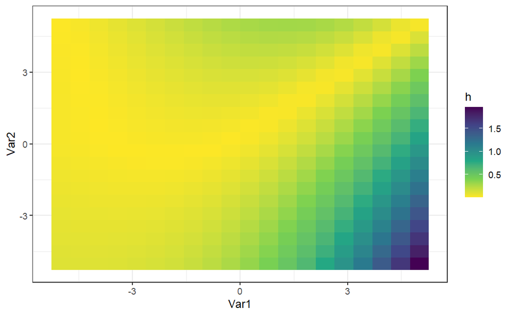

```r
plot_map(H(matrix(c(0.8,0.8), nrow=1)))
```

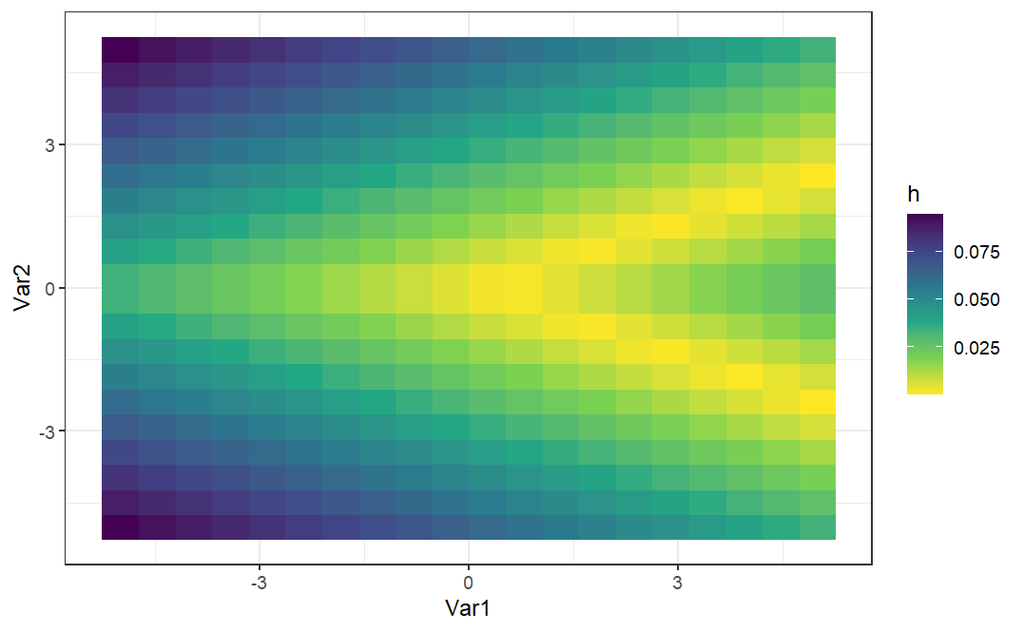

```r
plot_map(H(matrix(c(0,0.3), nrow=1)))
```

## Design of experiments

Sobol sequence of 200 points

```r
design = sobol(n=200,dim = 2)*2-1

outputs = H(design)
```

## Tuning of the FPCA parameters

### Tuning with rmse

For every pair $(\tilde{K},n_{\mathrm{pc}})$, we obtain $m$ predicted maps by loo, k_fold, training_test

We can compute the RMSE map:
$$y^{\mathrm{RMSE}} = \sqrt{\frac{1}{m}
\sum_{i=1}^{m} (y_{i} - \hat{y}_{i})^2}.$$

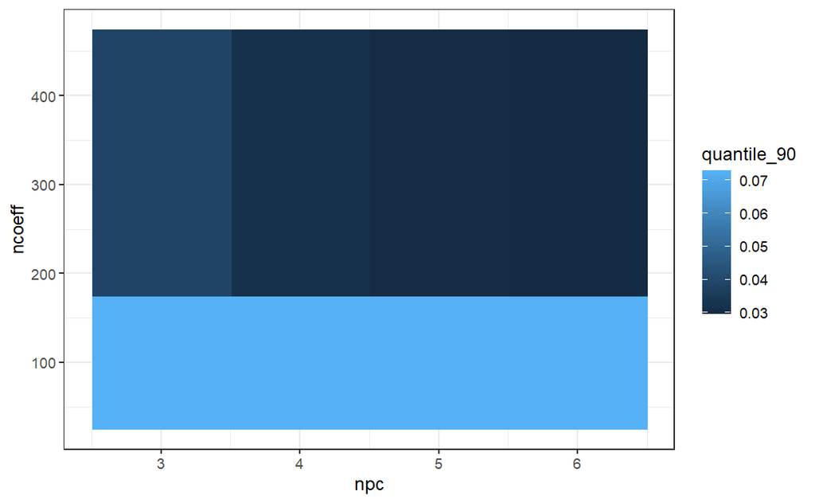

```r
set.seed(15)
list_rmse_loo = rmse_loo(
  outputs = outputs,
  design = design,
  npc_vec = 3:6,
  ncoeff_vec = c(100,250,400),
  return_pred = TRUE)


quantile_90 = sapply(list_rmse_loo$outputs_rmse,
                     function(x){quantile(x, 1)[[1]]})

df_rmse = as.data.frame(cbind(list_rmse_loo$grid_cv, quantile_90))

ggplot(data = df_rmse) + geom_raster(aes(x = npc, y = ncoeff, fill = quantile_90)) + theme_bw()
```

We select $n_{coeff} = 250$ and $n_{pc} = 6$.

We plot the rmse map.

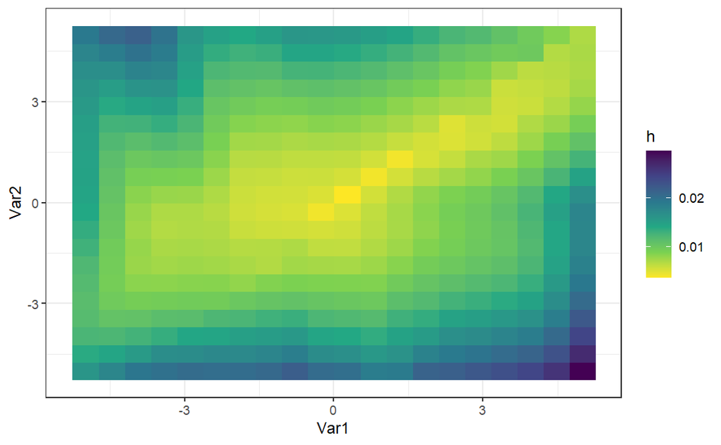

```r
idx = which(df_rmse$ncoeff == 250 & df_rmse$npc == 6)

rmse_map = list_rmse_loo$outputs_rmse[[idx]]
loo_maps = list_rmse_loo$outputs_pred[[idx]]

plot_map(rmse_map)
```

And we print $y_{k}$ and $\hat{y}_{k}$ with $k = \underset{i = 1,\dots,m}{argmax}\mid \mid y_{i}-\hat{y}_{i}\mid\mid$

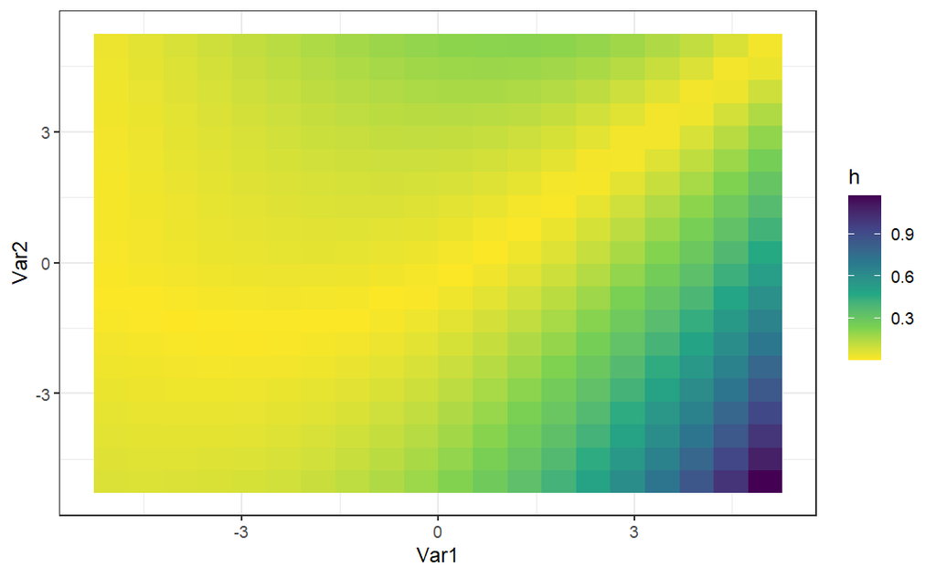

```r
distance_func = function(A1,A2){return(sqrt(sum((A1-A2)^2)))}

error_loo = Vectorize(function(i){distance_func(loo_maps[,,i], outputs[,,i])})(1:dim(loo_maps)[3])
plot_map(outputs[,,which.max(error_loo)])
```

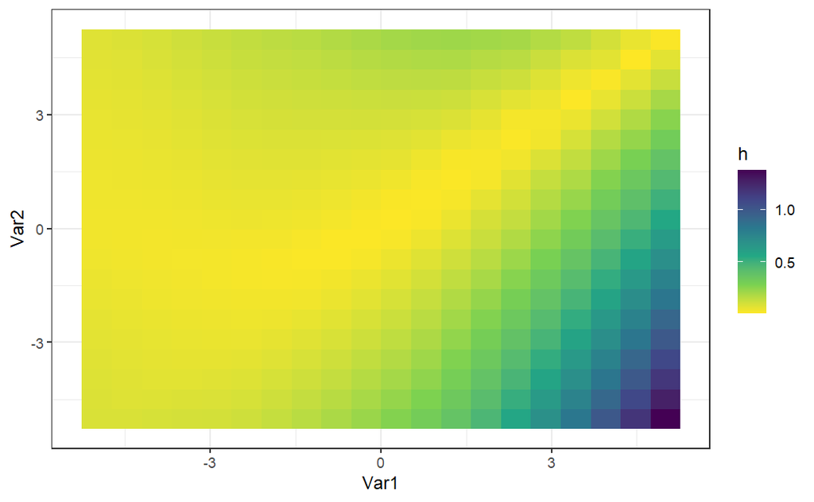

```r
plot_map(loo_maps[,,which.max(error_loo)])
```

We then build the metamodel.

For each pca axis, we plot the LOO predictions vs the true values.

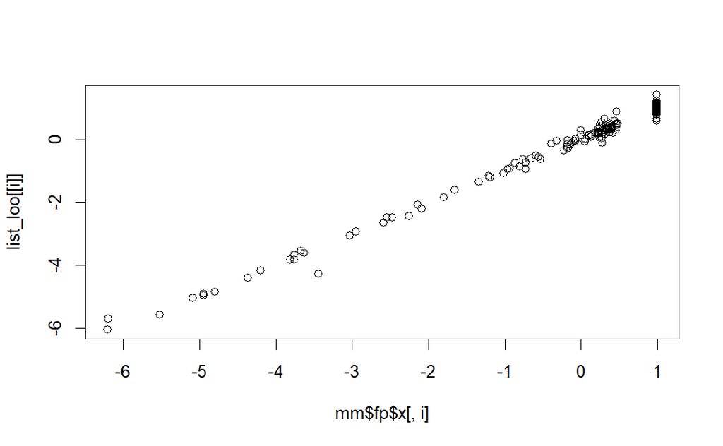

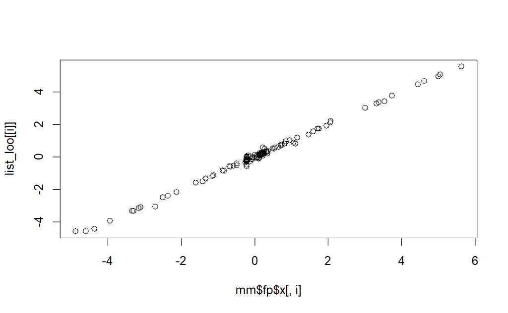

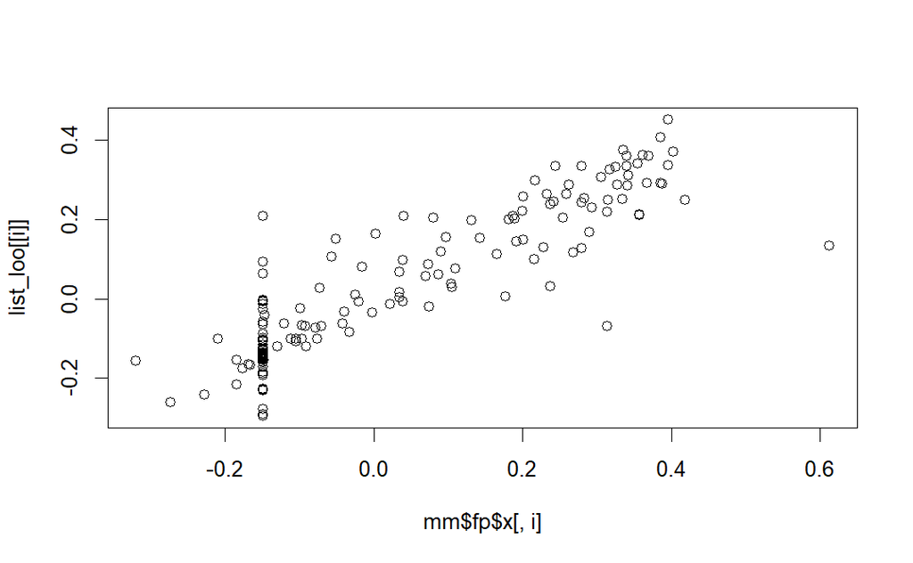

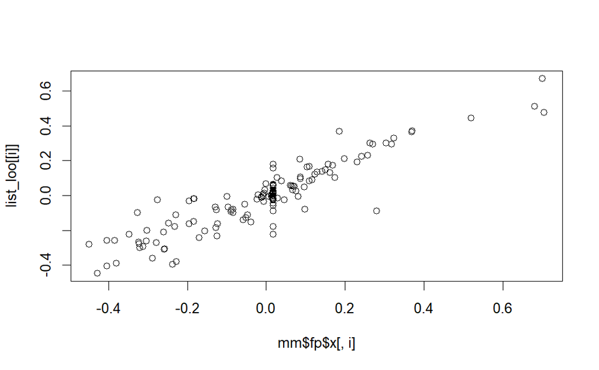

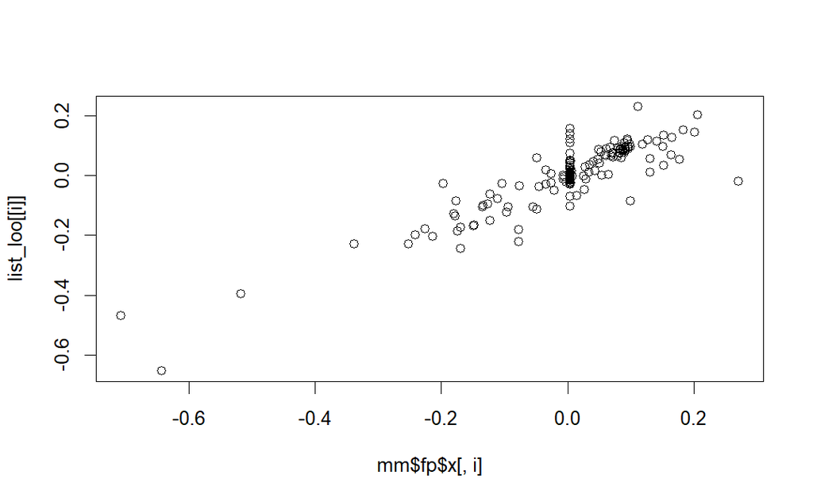

```r
mm = fit_metamodel(design_train = design, outputs_train = outputs, ncoeff = 250, npc = 6, kernel = "matern5_2")


list_loo = list()
for(i in 1:length(mm$model)){
 list_loo[[i]] = mm$model[[i]]$leaveOneOutVec(theta = mm$model[[i]]$theta())$mean
 plot(x = mm$fp$x[,i], y = list_loo[[i]])
}
```

[figure not shown]

```r
NA
```

### Tuning with probabilities

FunQuant offers the possibilities to tune the hyperparameters regarding the predicted membership probabilities for a given set of prototypes.

We can first quantize $H(X)$ with the training maps. The design of experiments can be seen as a uniform distribution, that we use for the importance sampling weights.

```r
g = function(x){
  if(sum(x > -1) == length(x) & sum(x < 1) == length(x)){return(1/4)}
  else{return(0)}
}

density_ratio = compute_density_ratio(f = fX,
                                      g = g, inputs = design)
```

```r
set.seed(1)
res_proto_1 = find_prototypes(nb_cells = 6,data = outputs, multistart = 5,density_ratio = density_ratio)
```

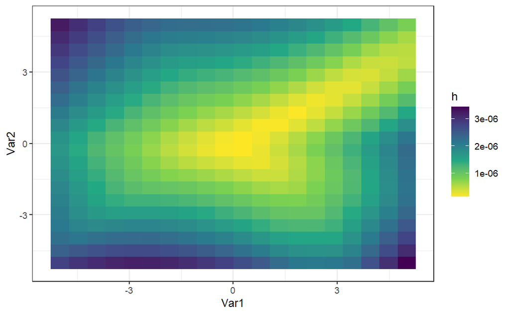

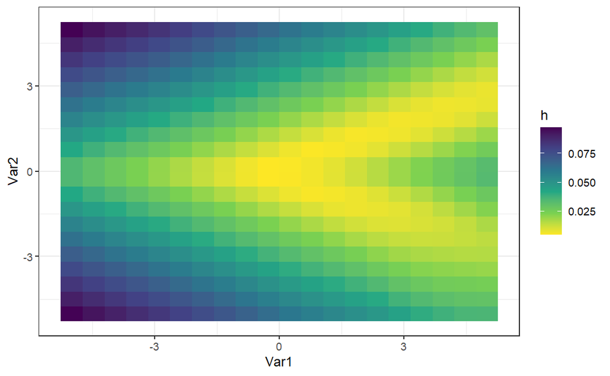

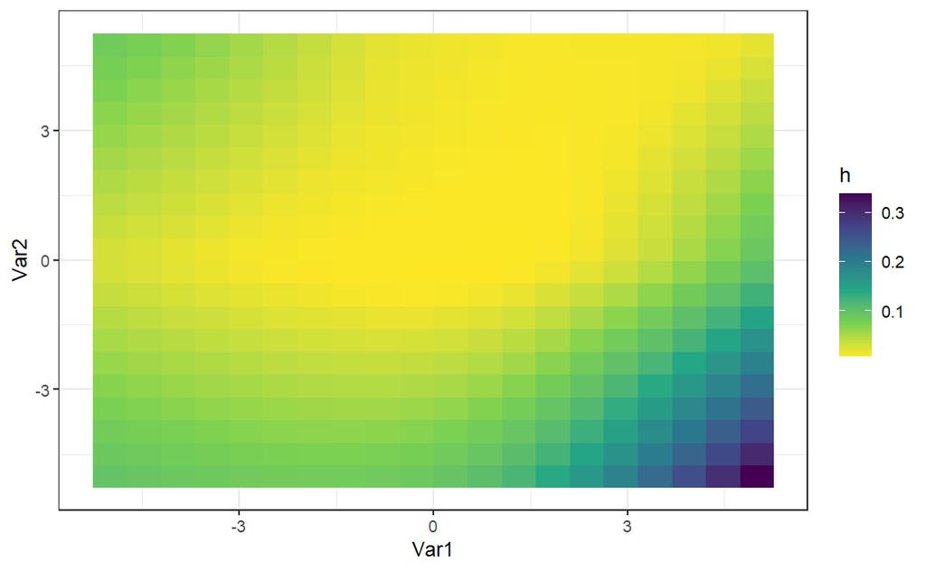

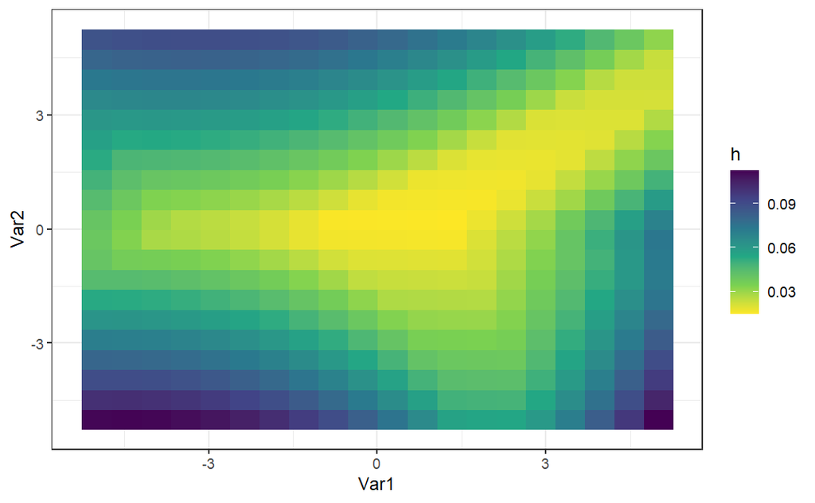

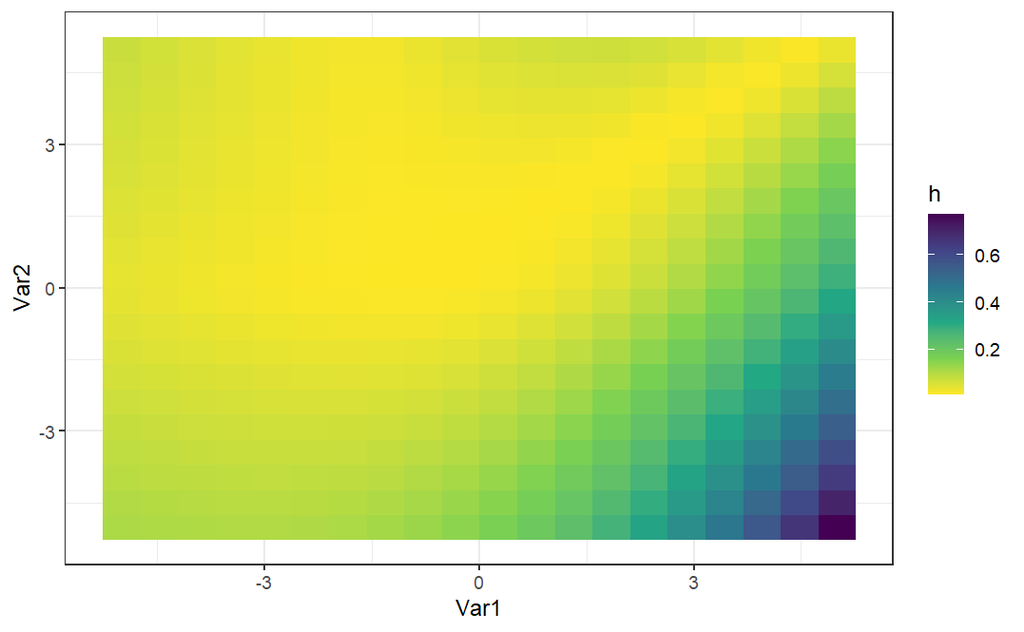

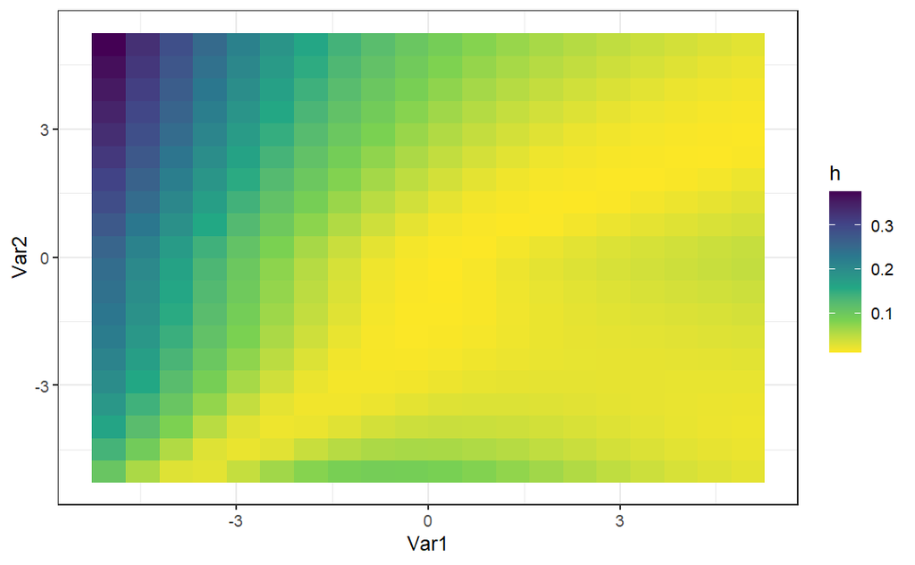

```r
for(i in 1:length(res_proto_1$prototypes)){print(plot_map(res_proto_1$prototypes[[i]]))}
```

```r
res_proto_1$probas
```

```
[1] 0.9660361247 0.0331117355 0.0010479795 0.0115366353 0.0003660801
[6] 0.0016393326
```

```r
set.seed(10)
list_probas_loo = probas_loo(
  outputs = outputs,
  design = design,
  density_ratio = density_ratio,
  prototypes = res_proto_1$prototypes,
  npc_vec = 3:6,
  ncoeff_vec = c(100,250,400))

list_probas_loo$error
```

| ncoeff | npc | 1 | 2 | 3 | 4 | 5 | 6 |
| --- | --- | --- | --- | --- | --- | --- | --- |
| 100 | 3 | 0.006125355 | 0.4305926 | 0.06802295 | 0.7155030 | 0 | 0.008887564 |
| 250 | 3 | 0.006125355 | 0.3379946 | 0.06802295 | 0.4497341 | 0 | 0.008887564 |
| 400 | 3 | 0.006125355 | 0.3379946 | 0.06802295 | 0.4497341 | 0 | 0.008887564 |
| 100 | 4 | 0.006125355 | 0.3381984 | 0.06802295 | 0.4515820 | 0 | 0.000000000 |
| 250 | 4 | 0.006125355 | 0.3381984 | 0.06802295 | 0.4515820 | 0 | 0.000000000 |
| 400 | 4 | 0.006125355 | 0.3381984 | 0.06802295 | 0.4515820 | 0 | 0.000000000 |
| 100 | 5 | 0.017096757 | 0.6582895 | 0.06802295 | 0.4515820 | 0 | 0.000000000 |
| 250 | 5 | 0.017096757 | 0.6582895 | 0.06802295 | 0.4515820 | 0 | 0.000000000 |
| 400 | 5 | 0.017096757 | 0.6582895 | 0.06802295 | 0.4515820 | 0 | 0.000000000 |
| 100 | 6 | 0.017096757 | 0.6582895 | 0.06802295 | 0.4515820 | 0 | 0.000000000 |

[output cut: 2 more lines]

```r
NA
NA
```

## Add classification

We can add a classification step to better predict the empty maps.

We will create two classes:

- The maps for which the sum of the pixels is < 0.01
- The maps for which the sum of the pixels is > 0.01

```r
sum_depth = Vectorize(function(i){
  sum(outputs[,,i])})(1:dim(outputs)[3])
```

We test the following parameters of the random forest:

- classwt = c(0.1,0.9), c(0.3,0.7), c(0.5,0.5), c(0.7,0.3), c(0.9,0.1)
- nodesize = c(1,3,5)

And for each pair of hyperparameters, we count the number of missclassified elements

```r
set.seed(1)

df_search = expand.grid(classwt1 = seq(0.1 ,0.9 ,0.2), nodesize = c(1 ,3 ,5))
list_search = list ("nodesize" = as.list(df_search[ ,2]), "classwt" = lapply(1:nrow(df_search), function(i){c(df_search[i ,1] , 1-df_search[i,1])}))

rf_kfold = rf_classif_k_fold(x = design, y = as.factor(sum_depth > 0.01), list_search = list_search, nb_folds = 10)

sapply(1: length(rf_kfold), function(i){sum((sum_depth > 0.01) != (rf_kfold[[i]] - 1))})
```

```
 [1] 1 1 1 1 1 1 1 1 1 1 1 1 1 1 1
```

All the pairs lead to the same result, one element is missclassified.

For the default pair of hyperparameters, classwt = c(0.5,0.5) and nodesize = 1, we observe the k-fold rmse map. And we do the same without the classification to compare

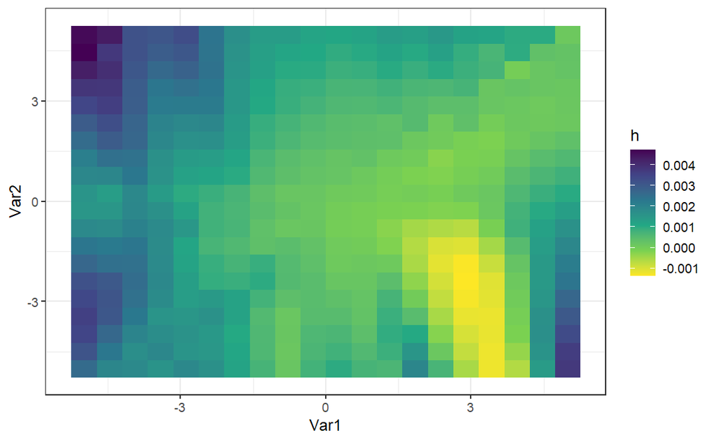

```r
set.seed(10)
kfold_classif = rf_rmse_k_fold(design= design, outputs = outputs, list_search = list("nodesize" = as.list(1), "classwt" = list(c(0.5,0.5))), nb_folds = 10, threshold_classification = 0.01, threshold_fpca = 0.01, ncoeff = 250, npc=6, return_pred = TRUE)

kfold_noclassif = rmse_k_fold(design = design, outputs = outputs, nb_folds = 10,npc_vec = 6,ncoeff_vec = 250)

plot_map(kfold_noclassif$outputs_rmse[[1]]-kfold_classif$outputs_rmse[[1]])
```

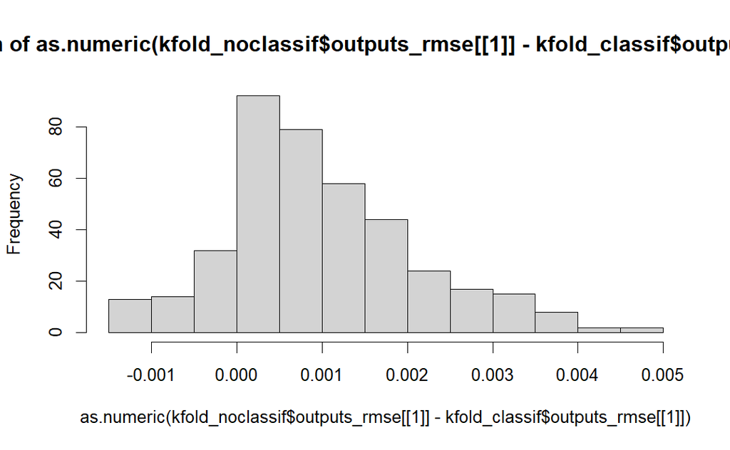

```r
hist(as.numeric(kfold_noclassif$outputs_rmse[[1]]-kfold_classif$outputs_rmse[[1]]))
```

```r
set.seed(3)
proba_error = rf_probas_k_fold(design= design, outputs = outputs, list_search = list("nodesize" = as.list(1), "classwt" = list(c(0.5,0.5))), nb_folds = 10, density_ratio = density_ratio, prototypes = res_proto_1$prototypes, threshold_classification = 0.01, threshold_fpca = 0.01, ncoeff = 250, npc=6, return_pred = FALSE)


proba_error$error
```

| 1 | 2 | 3 | 4 | 5 | 6 |
| --- | --- | --- | --- | --- | --- |
| 0.002527399 | 0.03032959 | 0.0519298 | 0.1198679 | 0 | 0 |